# Algorithm Theory and Mathematical Foundation

Zaoqu Liu

2026-01-23

## Overview

The **scTenifoldKnk** workflow consists of six main steps:

1. **Quality Control** - Filter cells and genes
2. **Network Construction** - Build gene regulatory networks using PCR
3. **Tensor Decomposition** - Denoise networks via CP decomposition
4. **Virtual Knockout** - Simulate gene knockout
5. **Manifold Alignment** - Align WT and KO networks
6. **Differential Regulation** - Identify affected genes

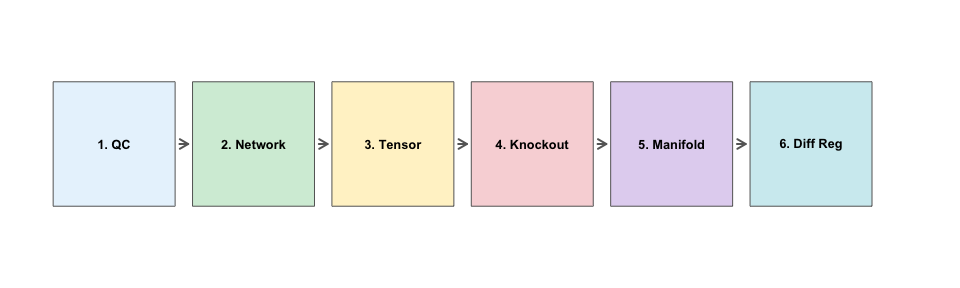

## Step 1: Quality Control

### Mathematical Formulation

Let $X \in \mathbb{R}^{G \times C}$ be the count matrix where $G$ is the number of genes and $C$ is the number of cells.

**Library Size Filter:**
$$L_j = \sum_{i=1}^{G} X_{ij}, \quad \text{keep
cell } j \text{ if } L_j \geq L_{min}$$

**Gene Detection Filter:**
$$D_i = \sum_{j=1}^{C} \mathbb{1}(X_{ij} > 0),
\quad \text{keep gene } i \text{ if } D_i \geq D_{min}$$

**Mitochondrial Content Filter:**
$$MT_j = \frac{\sum_{i \in MT} X_{ij}}{L_j}, \quad
\text{keep cell } j \text{ if } MT_j \leq MT_{max}$$

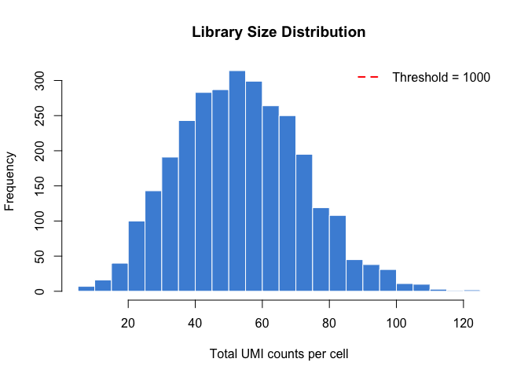

```r
library(scTenifoldKnk)

# Load data
data_path <- system.file("single-cell/example.csv", package = "scTenifoldKnk")
scRNAseq <- as.matrix(read.csv(data_path, row.names = 1))

# Compute library sizes
library_sizes <- colSums(scRNAseq)

# Visualize library size distribution
hist(library_sizes, breaks = 30, col = "#4A90D9", border = "white",
     main = "Library Size Distribution",
     xlab = "Total UMI counts per cell")
abline(v = 1000, col = "red", lwd = 2, lty = 2)
legend("topright", "Threshold = 1000", col = "red", lty = 2, lwd = 2, bty = "n")
```

## Step 2: Network Construction (Principal Component Regression)

### Algorithm

For each gene $k$, we perform leave-one-out principal component regression:

1. **Center and scale** the expression matrix $X$
2. **Exclude gene $k$**: $X_{-k} \in \mathbb{R}^{C \times (G-1)}$
3. **Compute SVD**: $X_{-k} = U \Sigma V^T$
4. **Extract top $p$ components**: $PC = U_p \Sigma_p$
5. **Regress gene $k$ on PCs**:
   $$\beta = (PC^T PC)^{-1} PC^T
   y_k$$
6. **Transform back**: $W_{k,-k} = V_p \beta$

### Mathematical Derivation

The network weight $W_{ij}$ represents the regulatory relationship:

$$W_{ij} = \text{Cov}(X_i, X_j |
PC_{-i})$$

This captures the conditional covariance between genes through the principal component space.

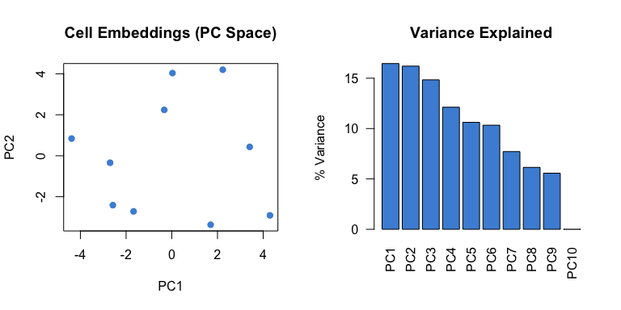

```r
# Illustrate PCA on gene expression
set.seed(42)
X <- matrix(rpois(500, 10), nrow = 50, ncol = 10)
rownames(X) <- paste0("Gene", 1:50)
X <- X[rowSums(X) > 0, ]

# Standardize
X_scaled <- scale(t(X))

# PCA
pca <- prcomp(X_scaled, center = FALSE)

# Visualize
par(mfrow = c(1, 2))

# PC scores
plot(pca$x[, 1], pca$x[, 2],
     pch = 19, col = "#4A90D9",
     xlab = "PC1", ylab = "PC2",
     main = "Cell Embeddings (PC Space)")

# Variance explained
var_explained <- (pca$sdev^2 / sum(pca$sdev^2)) * 100
barplot(var_explained[1:10],
        names.arg = paste0("PC", 1:10),
        col = "#4A90D9",
        main = "Variance Explained",
        ylab = "% Variance",
        las = 2)
```

## Step 3: Tensor Decomposition (CP-ALS)

### CANDECOMP/PARAFAC Decomposition

Given a 3-way tensor $\mathcal{X} \in \mathbb{R}^{G \times G \times N}$ (networks stacked along third mode):

$$\mathcal{X} \approx \sum_{r=1}^{R}
\lambda_r \cdot a_r \otimes b_r \otimes c_r$$

where: - $a_r, b_r \in \mathbb{R}^G$ are gene factor vectors - $c_r \in \mathbb{R}^N$ are network weights - $\lambda_r$ are component weights - $\otimes$ denotes outer product

### Alternating Least Squares (ALS) Algorithm

For each mode $n \in \{1, 2, 3\}$:

$$A^{(n)} \leftarrow X_{(n)}
(A^{(-n)})^{\dagger}$$

where $X_{(n)}$ is the mode-$n$ unfolding and $(A^{(-n)})^{\dagger}$ is the Khatri-Rao product pseudoinverse.

### Reconstruction

The denoised network is the weighted average:

$$\bar{W} = \frac{1}{N} \sum_{k=1}^{N}
\sum_{r=1}^{R} c_{kr} \cdot a_r b_r^T$$

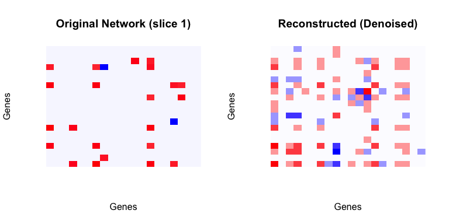

```r
# Build multiple networks
networks <- makeNetworksFast(X, nNet = 5, nCells = 8, nComp = 3,
                              verbose = FALSE, seed = 42)

# Tensor decomposition
td_result <- tensorDecomposition(networks, K = 3, maxIter = 100)

# Visualize reconstruction
par(mfrow = c(1, 2))

# Original (first network)
net1 <- as.matrix(networks[[1]])
image(net1[1:20, 1:20],
      col = colorRampPalette(c("blue", "white", "red"))(100),
      main = "Original Network (slice 1)",
      xlab = "Genes", ylab = "Genes", axes = FALSE)

# Reconstructed
recon <- as.matrix(td_result$X)
image(recon[1:20, 1:20],
      col = colorRampPalette(c("blue", "white", "red"))(100),
      main = "Reconstructed (Denoised)",
      xlab = "Genes", ylab = "Genes", axes = FALSE)
```

## Step 4: Virtual Knockout

### Implementation

The knockout operation sets all outgoing edges from gene $g$ to zero:

$$W^{KO}_{g, \cdot} = 0$$

This simulates the loss of regulatory capacity of gene $g$.

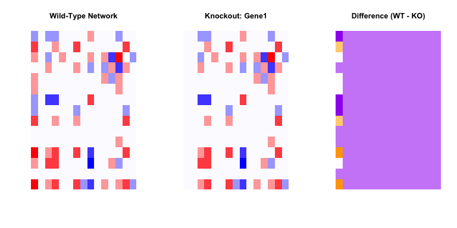

```r
# Get WT network
WT <- as.matrix(td_result$X)

# Perform knockout
KO <- WT
knockout_gene <- "Gene1"
if (knockout_gene %in% rownames(KO)) {
  ko_idx <- which(rownames(KO) == knockout_gene)
  KO[ko_idx, ] <- 0
}

# Visualize difference
par(mfrow = c(1, 3))

# WT
image(WT[1:15, 1:15],
      col = colorRampPalette(c("blue", "white", "red"))(100),
      main = "Wild-Type Network",
      axes = FALSE)

# KO
image(KO[1:15, 1:15],
      col = colorRampPalette(c("blue", "white", "red"))(100),
      main = paste("Knockout:", knockout_gene),
      axes = FALSE)

# Difference
diff_net <- WT - KO
image(diff_net[1:15, 1:15],
      col = colorRampPalette(c("purple", "white", "orange"))(100),
      main = "Difference (WT - KO)",
      axes = FALSE)
```

## Step 5: Manifold Alignment

### Non-linear Manifold Alignment (NLMA)

Given two networks $W^{WT}$ and $W^{KO}$, we construct a joint graph:

$$W = \begin{pmatrix} W^{WT} + I & \mu
L \\ \mu L^T & W^{KO} + I \end{pmatrix}$$

where $L$ is the alignment matrix and $\mu$ controls alignment strength.

### Spectral Embedding

Compute the graph Laplacian:
$$\mathcal{L}
= D - W$$

where $D_{ii} = \sum_j W_{ij}$.

The embedding is given by the eigenvectors corresponding to the smallest non-zero eigenvalues.

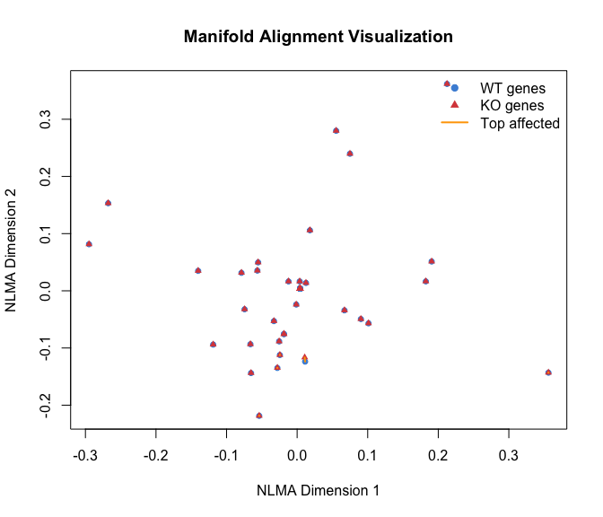

```r
# Perform manifold alignment
MA <- manifoldAlignment(Matrix::Matrix(WT, sparse = TRUE),
                        Matrix::Matrix(KO, sparse = TRUE),
                        d = 2)

# Extract WT and KO embeddings
n_genes <- nrow(WT)
WT_embed <- MA[1:n_genes, ]
KO_embed <- MA[(n_genes+1):(2*n_genes), ]

# Compute distances
distances <- sqrt(rowSums((WT_embed - KO_embed)^2))

# Plot
plot(WT_embed[, 1], WT_embed[, 2],
     pch = 19, col = "#4A90D9", cex = 0.8,
     xlab = "NLMA Dimension 1", ylab = "NLMA Dimension 2",
     main = "Manifold Alignment Visualization")
points(KO_embed[, 1], KO_embed[, 2],
       pch = 17, col = "#D94A4A", cex = 0.8)

# Draw connections for top affected genes
top_idx <- order(distances, decreasing = TRUE)[1:5]
for (i in top_idx) {
  lines(c(WT_embed[i, 1], KO_embed[i, 1]),
        c(WT_embed[i, 2], KO_embed[i, 2]),
        col = "orange", lwd = 2)
}

legend("topright",
       legend = c("WT genes", "KO genes", "Top affected"),
       col = c("#4A90D9", "#D94A4A", "orange"),
       pch = c(19, 17, NA), lty = c(NA, NA, 1), lwd = c(NA, NA, 2),
       bty = "n")
```

## Step 6: Differential Regulation Analysis

### Distance-Based Statistics

For each gene $i$, compute the Euclidean distance between WT and KO embeddings:

$$d_i = \|E^{WT}_i -
E^{KO}_i\|_2$$

### Fold Change

$$FC_i =
\frac{d_i^2}{\bar{d}_{-g}^2}$$

where $\bar{d}_{-g}^2 = \frac{1}{G-1}\sum_{j \neq g} d_j^2$ excludes the knockout gene.

### Statistical Testing

Under the null hypothesis, $FC$ follows a chi-square distribution:

$$FC \sim \chi^2_1$$

P-values are computed as:
$$p_i =
P(\chi^2_1 > FC_i)$$

### Multiple Testing Correction

Benjamini-Hochberg FDR:
$$p_{adj}^{(i)} =
\min\left(1, \frac{n \cdot p_{(i)}}{i}\right)$$

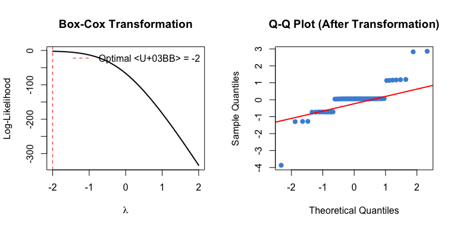

```r
# Compute statistics
names(distances) <- rownames(WT)

# Box-Cox transformation
distances_pos <- pmax(distances, 1e-10)
bc_result <- MASS::boxcox(distances_pos ~ 1, plotit = FALSE)
lambda_opt <- bc_result$x[which.max(bc_result$y)]

# Apply transformation
if (abs(lambda_opt) < 0.01) {
  transformed <- log(distances_pos)
} else {
  transformed <- distances_pos^lambda_opt
}

# Z-scores
Z <- scale(transformed)[, 1]

par(mfrow = c(1, 2))

# Box-Cox optimization
plot(bc_result$x, bc_result$y, type = "l", lwd = 2,
     xlab = expression(lambda), ylab = "Log-Likelihood",
     main = "Box-Cox Transformation")
abline(v = lambda_opt, col = "red", lty = 2)
legend("topright", paste("Optimal λ =", round(lambda_opt, 2)),
       col = "red", lty = 2, bty = "n")

# Q-Q plot
qqnorm(Z, main = "Q-Q Plot (After Transformation)", pch = 19, col = "#4A90D9")
qqline(Z, col = "red", lwd = 2)
```

## Summary

The scTenifoldKnk algorithm provides a mathematically rigorous framework for:

1. **Network inference** via principal component regression
2. **Noise reduction** via tensor decomposition
3. **Comparative analysis** via manifold alignment
4. **Statistical testing** via chi-square distribution

This enables researchers to predict gene knockout effects *in silico*, saving time and resources compared to wet-lab experiments.

## References

1. Osorio, D., et al. (2020). scTenifoldKnk: An efficient virtual knockout tool for gene function predictions via single-cell gene regulatory network perturbation.
2. Kolda, T. G., & Bader, B. W. (2009). Tensor decompositions and applications. SIAM review.
3. Box, G. E., & Cox, D. R. (1964). An analysis of transformations. Journal of the Royal Statistical Society.